# Actividad 3 - Aprendizaje Automático

## Detección de anomalías y Técnicas de agrupamiento

- Fernando Palomino Cobo
- Mónica Hazeu
- Carles Serra
- Xavier Castilla

Se importan las librerías necesarias.

```python
import numpy as np
import pandas as pd
import matplotlib.pyplot as plt
import seaborn as sns

from sklearn.preprocessing import StandardScaler

from sklearn.cluster import KMeans
from sklearn.cluster import AgglomerativeClustering
from sklearn.cluster import DBSCAN
from sklearn.ensemble import IsolationForest
from sklearn.neighbors import LocalOutlierFactor

from sklearn.metrics import confusion_matrix, accuracy_score, f1_score
```

## 1. Análisis de los datos

Se importa el dataset en un DataFrame de pandas:

```python
dataset = pd.read_csv('creditcardcsvpresent.csv')
```

```python
#para que se muestren todas las columnas en lugar de un resumen (se limita a 30 filas)
pd.set_option("display.max_rows", 30, "display.max_columns", None)
```

```python
#visualización del Dataframe
dataset
```

|  | Merchant_id | Transaction date | Average Amount/transaction/day | Transaction_amount | Is declined | Total Number of declines/day | isForeignTransaction | isHighRiskCountry | Daily_chargeback_avg_amt | 6_month_avg_chbk_amt | 6-month_chbk_freq | isFradulent |
| --- | --- | --- | --- | --- | --- | --- | --- | --- | --- | --- | --- | --- |
| 0 | 3160040998 | NaN | 100.0 | 3000.0 | N | 5 | Y | Y | 0 | 0.0 | 0 | Y |
| 1 | 3160040998 | NaN | 100.0 | 4300.0 | N | 5 | Y | Y | 0 | 0.0 | 0 | Y |
| 2 | 3160041896 | NaN | 185.5 | 4823.0 | Y | 5 | N | N | 0 | 0.0 | 0 | Y |
| 3 | 3160141996 | NaN | 185.5 | 5008.5 | Y | 8 | N | N | 0 | 0.0 | 0 | Y |
| 4 | 3160241992 | NaN | 500.0 | 26000.0 | N | 0 | Y | Y | 800 | 677.2 | 6 | Y |
| ... | ... | ... | ... | ... | ... | ... | ... | ... | ... | ... | ... | ... |
| 3070 | 6661273532 | NaN | 500.0 | 11000.0 | Y | 0 | N | N | 754 | 585.0 | 7 | N |
| 3071 | 6661273532 | NaN | 800.0 | 0.0 | Y | 0 | N | N | 754 | 585.0 | 7 | N |
| 3072 | 6661273533 | NaN | 800.0 | 20800.0 | Y | 0 | N | N | 754 | 585.0 | 7 | N |
| 3073 | 6661273532 | NaN | 1500.0 | 12000.0 | Y | 0 | Y | Y | 754 | 585.0 | 7 | N |
| 3074 | 6661273533 | NaN | 1500.0 | 36000.0 | Y | 0 | Y | Y | 754 | 585.0 | 7 | N |

3075 rows × 12 columns

```python
dataset.columns
```

```
Index(['Merchant_id', 'Transaction date', 'Average Amount/transaction/day',
       'Transaction_amount', 'Is declined', 'Total Number of declines/day',
       'isForeignTransaction', 'isHighRiskCountry', 'Daily_chargeback_avg_amt',
       '6_month_avg_chbk_amt', '6-month_chbk_freq', 'isFradulent'],
      dtype='object')
```

```python
dataset.info()
```

```
<class 'pandas.core.frame.DataFrame'>
RangeIndex: 3075 entries, 0 to 3074
Data columns (total 12 columns):
 #   Column                          Non-Null Count  Dtype
---  ------                          --------------  -----
 0   Merchant_id                     3075 non-null   int64
 1   Transaction date                0 non-null      float64
 2   Average Amount/transaction/day  3075 non-null   float64
 3   Transaction_amount              3075 non-null   float64
 4   Is declined                     3075 non-null   object
 5   Total Number of declines/day    3075 non-null   int64
 6   isForeignTransaction            3075 non-null   object
 7   isHighRiskCountry               3075 non-null   object
 8   Daily_chargeback_avg_amt        3075 non-null   int64
 9   6_month_avg_chbk_amt            3075 non-null   float64
 10  6-month_chbk_freq               3075 non-null   int64
 11  isFradulent                     3075 non-null   object
dtypes: float64(4), int64(4), object(4)
memory usage: 288.4+ KB
```

Inmediatamente, se puede ver que se puede eliminar la columna de *Transaction date*, ya que no tiene ningún valor no-nulo.

```python
dataset = dataset.drop(columns='Transaction date')
```

```python
dataset.info()
```

```
<class 'pandas.core.frame.DataFrame'>
RangeIndex: 3075 entries, 0 to 3074
Data columns (total 11 columns):
 #   Column                          Non-Null Count  Dtype
---  ------                          --------------  -----
 0   Merchant_id                     3075 non-null   int64
 1   Average Amount/transaction/day  3075 non-null   float64
 2   Transaction_amount              3075 non-null   float64
 3   Is declined                     3075 non-null   object
 4   Total Number of declines/day    3075 non-null   int64
 5   isForeignTransaction            3075 non-null   object
 6   isHighRiskCountry               3075 non-null   object
 7   Daily_chargeback_avg_amt        3075 non-null   int64
 8   6_month_avg_chbk_amt            3075 non-null   float64
 9   6-month_chbk_freq               3075 non-null   int64
 10  isFradulent                     3075 non-null   object
dtypes: float64(3), int64(4), object(4)
memory usage: 264.4+ KB
```

### 1.1. Datos estadísticos de las variables numéricas:

```python
dataset.describe()
```

|  | Merchant_id | Average Amount/transaction/day | Transaction_amount | Total Number of declines/day | Daily_chargeback_avg_amt | 6_month_avg_chbk_amt | 6-month_chbk_freq |
| --- | --- | --- | --- | --- | --- | --- | --- |
| count | 3.075000e+03 | 3075.000000 | 3075.000000 | 3075.000000 | 3075.000000 | 3075.000000 | 3075.000000 |
| mean | 5.026634e+09 | 515.026556 | 9876.399210 | 0.957398 | 55.737561 | 40.022407 | 0.391870 |
| std | 9.870778e+08 | 291.906978 | 10135.331016 | 2.192391 | 206.634779 | 155.968840 | 1.548479 |
| min | 3.160041e+09 | 4.011527 | 0.000000 | 0.000000 | 0.000000 | 0.000000 | 0.000000 |
| 25% | 4.170814e+09 | 269.788047 | 2408.781147 | 0.000000 | 0.000000 | 0.000000 | 0.000000 |
| 50% | 5.025578e+09 | 502.549575 | 6698.891856 | 0.000000 | 0.000000 | 0.000000 | 0.000000 |
| 75% | 5.889625e+09 | 765.272803 | 14422.568935 | 0.000000 | 0.000000 | 0.000000 | 0.000000 |
| max | 6.665906e+09 | 2000.000000 | 108000.000000 | 20.000000 | 998.000000 | 998.000000 | 9.000000 |

### 1.2. Datos de las variables categóricas:

```python
dataset.describe(include=['O'])
```

|  | Is declined | isForeignTransaction | isHighRiskCountry | isFradulent |
| --- | --- | --- | --- | --- |
| count | 3075 | 3075 | 3075 | 3075 |
| unique | 2 | 2 | 2 | 2 |
| top | N | N | N | N |
| freq | 3018 | 2369 | 2870 | 2627 |

Se encuentra la frecuencia de cada valor en las variables categóricas:

```python
dataset_cat = dataset.describe(include=['O']).columns #categorical columns

for column in dataset_cat:
    print("\033[1m" + column + "\033[0m") #column in bold
    print(dataset[column].value_counts(dropna = False)) #frequencies of categories
    print('\n')
```

```
Is declined
N    3018
Y      57
Name: Is declined, dtype: int64


isForeignTransaction
N    2369
Y     706
Name: isForeignTransaction, dtype: int64


isHighRiskCountry
N    2870
Y     205
Name: isHighRiskCountry, dtype: int64


isFradulent
N    2627
Y     448
Name: isFradulent, dtype: int64
```

```python
#comprobamos que están incluidas todas las columnas
print(len(dataset.columns), ' = ', len(dataset.describe().columns) + len(dataset.describe(include=['O']).columns))
```

```
11  =  11
```

Se puede hacer un plot de la distribución de las variables:

[figure not shown]

[figure not shown]

```python
fig, ax = plt.subplots(2, 5, figsize=(15,5))

for column in range(5):
    for row in range(2):
        if dataset[dataset.columns[column+5*row]].dtype == 'int64' or dataset[dataset.columns[column+5*row]].dtype == 'float64':
            ax[row, column].hist(dataset[dataset.columns[column+5*row]])
        else:
            ax[row, column].bar(dataset[dataset.columns[column+5*row]].unique(),
                                dataset[dataset.columns[column+5*row]].value_counts())
            ax[row, column].set_xticks(dataset[dataset.columns[column+5*row]].unique())

        ax[row, column].set_title(dataset.columns[column+5*row])

fig.tight_layout()

plt.show()

fig2, ax2 = plt.subplots(1, 1, figsize=(5.5, 2.5))

ax2.bar(dataset[dataset.columns[10]].unique(), dataset[dataset.columns[10]].value_counts())
ax2.set_xticks(dataset[dataset.columns[10]].unique())
ax2.set_title(dataset.columns[10])

fig2.tight_layout()
plt.show();
```

Como se puede ver, para la mayoría de las variables los datos están bastante desequilibrados, y es por esto que serán útiles las técnicas de detección de anomalías o de clustering frente a técnicas de aprendizaje supervisado.

A continuación, se puede ver la distribución de cada variable para los datos fraudulentos y los no fraudulentos, viendo así que variables pueden tener una mayor correlación.

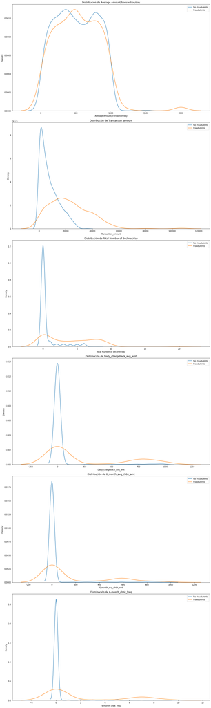

```python
variables_num = list(dataset._get_numeric_data().columns[1:])
fig, axs = plt.subplots(len(variables_num), 1, figsize=(15, 50))

count = 0
for column in variables_num:
    # No fraudulentas
    sns.kdeplot(
    dataset[dataset['isFradulent']=='N'][column],
    ax=axs[count])

    # Faudulentas
    fp = sns.kdeplot(
        dataset[dataset['isFradulent']=='Y'][column],
        ax=axs[count])

    fp.legend(['No fraudulento','Fraudulento'])
    fp.set_title(f'Distribución de {column}')
    count += 1

plt.tight_layout()
```

### 1.3. Correlaciones entre variables

Para encontrar las correlaciones, antes se van a convertir las variables categóricas a valores numéricos. Todas las variables categóricas son binarias (Y/N), por lo que la conversión es fácil.

```python
dataset['Is declined'] = dataset['Is declined'].map(dict(Y=1, N=0))
dataset['isForeignTransaction'] = dataset['isForeignTransaction'].map(dict(Y=1, N=0))
dataset['isHighRiskCountry'] = dataset['isHighRiskCountry'].map(dict(Y=1, N=0))
dataset['isFradulent'] = dataset['isFradulent'].map(dict(Y=1, N=0))
```

```python
dataset.info()
```

```
<class 'pandas.core.frame.DataFrame'>
RangeIndex: 3075 entries, 0 to 3074
Data columns (total 11 columns):
 #   Column                          Non-Null Count  Dtype
---  ------                          --------------  -----
 0   Merchant_id                     3075 non-null   int64
 1   Average Amount/transaction/day  3075 non-null   float64
 2   Transaction_amount              3075 non-null   float64
 3   Is declined                     3075 non-null   int64
 4   Total Number of declines/day    3075 non-null   int64
 5   isForeignTransaction            3075 non-null   int64
 6   isHighRiskCountry               3075 non-null   int64
 7   Daily_chargeback_avg_amt        3075 non-null   int64
 8   6_month_avg_chbk_amt            3075 non-null   float64
 9   6-month_chbk_freq               3075 non-null   int64
 10  isFradulent                     3075 non-null   int64
dtypes: float64(3), int64(8)
memory usage: 264.4 KB
```

```python
dataset.head()
```

|  | Merchant_id | Average Amount/transaction/day | Transaction_amount | Is declined | Total Number of declines/day | isForeignTransaction | isHighRiskCountry | Daily_chargeback_avg_amt | 6_month_avg_chbk_amt | 6-month_chbk_freq | isFradulent |
| --- | --- | --- | --- | --- | --- | --- | --- | --- | --- | --- | --- |
| 0 | 3160040998 | 100.0 | 3000.0 | 0 | 5 | 1 | 1 | 0 | 0.0 | 0 | 1 |
| 1 | 3160040998 | 100.0 | 4300.0 | 0 | 5 | 1 | 1 | 0 | 0.0 | 0 | 1 |
| 2 | 3160041896 | 185.5 | 4823.0 | 1 | 5 | 0 | 0 | 0 | 0.0 | 0 | 1 |
| 3 | 3160141996 | 185.5 | 5008.5 | 1 | 8 | 0 | 0 | 0 | 0.0 | 0 | 1 |
| 4 | 3160241992 | 500.0 | 26000.0 | 0 | 0 | 1 | 1 | 800 | 677.2 | 6 | 1 |

```python
correlation = dataset.corr().abs() #matriz de correlación en valor absoluto

corr_unstack = correlation.unstack() #mostrar en forma de vector
corr_unstack[(corr_unstack>=0.75) & (corr_unstack<1)].sort_values(kind="quicksort", ascending=False).drop_duplicates() #mostrar valores por encima de 0.75
```

```
6_month_avg_chbk_amt  Daily_chargeback_avg_amt    0.953663
6-month_chbk_freq     Daily_chargeback_avg_amt    0.884611
                      6_month_avg_chbk_amt        0.851339
dtype: float64
```

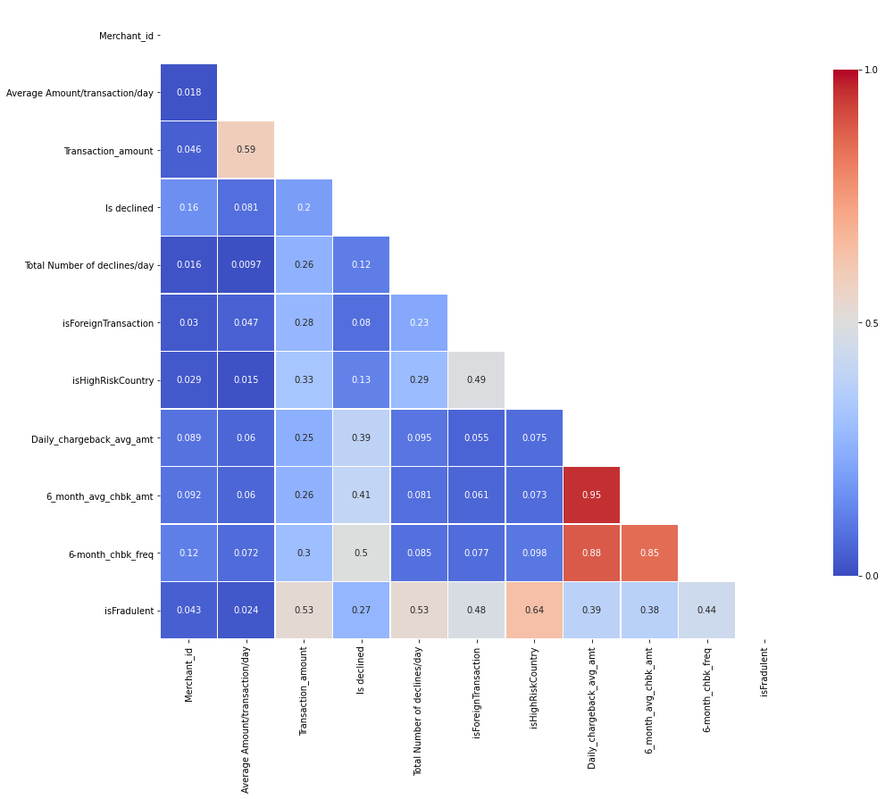

```python
#para ver gráficamente la matriz de correlación
mask = np.triu(np.ones(correlation.shape)).astype(np.bool) #máscara para ver sólo la parte inferior y eliminar duplicados

f, ax = plt.subplots(figsize=(15, 20))

ax = sns.heatmap(correlation, mask=mask, square=True, linewidths=.6, linecolor='white',
                 cmap='coolwarm', cbar_kws={'shrink': .4, 'ticks': [0, 0.5, 1]}, vmin=0, vmax=1,
                 annot=True, annot_kws={"size": 10})

ax.set_yticklabels(correlation.columns, rotation=0)
ax.set_xticklabels(correlation.columns, rotation=90)
plt.tight_layout()
```

**Análisis de variables:**

Las variables con mayor correlación son la cuantía media de los contracargos diarios y la cuantía media de los contracargos durante 6 meses, con una correlación del 95%. Estas dos variables, realmente, están definiendo el mismo fenómeno pero en intervalos de tiempo distintos. De hecho, si se observan las gráficas que describen los datos de cada variable se observa que tienen formas casi idénticas. Se va a eliminar la variable _6_month_avg_chbk*amt*, ya que se consideran más relevantes los datos diarios para la predicción de fraudes que una media con menos picos a largo plazo.

La siguiente correlación más alta es _6-month_chbk*freq* con _Daily_chargeback_avg*amt*. Se va a eliminar la primera variable de las dos, ya que tienen distribuciones idénticas.

La última correlación alta no es necesario tenerla en cuenta, ya que ya se ha mencionado que se eliminarán ambas variables involucradas.

```python
dataset = dataset.drop(columns='6-month_chbk_freq')
dataset = dataset.drop(columns='6_month_avg_chbk_amt')
```

```python
dataset.columns
```

```
Index(['Merchant_id', 'Average Amount/transaction/day', 'Transaction_amount',
       'Is declined', 'Total Number of declines/day', 'isForeignTransaction',
       'isHighRiskCountry', 'Daily_chargeback_avg_amt', 'isFradulent'],
      dtype='object')
```

Por último, se va a eliminar _Merchant*ID*. Se ha observado que esta variable no tiene ningún efecto sobre los casos fraudulentos y es solo un ID que no se debe tener en cuenta en la predicción.

```python
dataset = dataset.drop(columns='Merchant_id')
```

### 1.4. Tratamiento de missing

```python
#columnas con valores NAN en porcentaje
dataset.isna().sum()[dataset.isna().sum()>0] / len(dataset) * 100
```

```
Series([], dtype: float64)
```

Como se puede ver, no hay ninguna variable con valores NaN, por lo que no es necesario el tratamiento de missing.

## 2. Técnicas de clústering

Como técnicas de clustering, se van a usar los algoritmos *k-means*, *hierarchical clustering* y DBSCAN para comparar la performance de cada uno.

### 2.1. Preparación de los datos

No se debe incluir la variable Is Fraudulent, ya que el objetivo es crear clústers de forma no supervisada.

```python
X = dataset.iloc[:, :-1]
y = dataset.iloc[:, -1:]
```

```python
X.head()
```

|  | Average Amount/transaction/day | Transaction_amount | Is declined | Total Number of declines/day | isForeignTransaction | isHighRiskCountry | Daily_chargeback_avg_amt |
| --- | --- | --- | --- | --- | --- | --- | --- |
| 0 | 100.0 | 3000.0 | 0 | 5 | 1 | 1 | 0 |
| 1 | 100.0 | 4300.0 | 0 | 5 | 1 | 1 | 0 |
| 2 | 185.5 | 4823.0 | 1 | 5 | 0 | 0 | 0 |
| 3 | 185.5 | 5008.5 | 1 | 8 | 0 | 0 | 0 |
| 4 | 500.0 | 26000.0 | 0 | 0 | 1 | 1 | 800 |

```python
y.head()
```

|  | isFradulent |
| --- | --- |
| 0 | 1 |
| 1 | 1 |
| 2 | 1 |
| 3 | 1 |
| 4 | 1 |

### 2.2. Modelo K-means

K-means es un algoritmo de clustering que separa los datos intentando buscar k clústers de la misma varianza, minimizando la *within-cluster-sum-of-squares*. En este caso, se conoce el número de clústers que se desea encontrar, en concreto 2 (Sí fraudulento, No fraudulento).

```python
kmeans = KMeans(n_clusters=2, init='k-means++', random_state=42) #k_means++ evita la trampa de la incialización aleatoria
y_kmeans = kmeans.fit_predict(X)
```

```python
np.unique(y_kmeans)
```

```
array([0, 1], dtype=int32)
```

```python
CM = confusion_matrix(y, y_kmeans)
print('Confusion matrix:\n', CM)
AC = accuracy_score(y, y_kmeans)
print('\n Accuracy: ', round(AC, 3))
Fsc = f1_score(y, y_kmeans)
print('\n F1-score: ', round(Fsc, 3))
```

```
Confusion matrix:
 [[2172  455]
 [ 147  301]]

 Accuracy:  0.804

 F1-score:  0.5
```

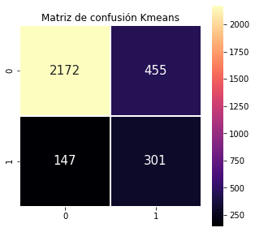

```python
fig, ax = plt.subplots(figsize=(5,5))

ax = sns.heatmap(CM, square=True, linewidths=.6, linecolor='white', cmap='magma',
            annot=True, annot_kws={"size": 15}, fmt='g')
ax.set_title('Matriz de confusión Kmeans', fontsize=12);
```

Como se puede ver, los resultados son mejorables. Dado que los clústers se están agrupando por distancias, y que K-means tiende a hacer clústers de forma circular, es posible que no se esté encontrando correctamente a los outliers porque no se les puede agrupar correctamente en el espacio de variables actual. Se va a probar a escalar las variables para ver si se obtienen de esta forma mejores resultados.

```python
sc = StandardScaler()
X_sc = sc.fit_transform(X)
```

```python
kmeans = KMeans(n_clusters=2, init='k-means++', random_state=42) #k_means++ evita la trampa de la incialización aleatoria
y_kmeans = kmeans.fit_predict(X_sc)
```

```python
np.unique(y_kmeans, return_counts=True)
```

```
(array([0, 1], dtype=int32), array([2711,  364]))
```

```python
CM = confusion_matrix(y, y_kmeans)
print('Confusion matrix:\n', CM)
AC = accuracy_score(y, y_kmeans)
print('\n Accuracy: ', round(AC, 3))
Fsc = f1_score(y, y_kmeans)
print('\n F1-score: ', round(Fsc, 3))
```

```
Confusion matrix:
 [[2606   21]
 [ 105  343]]

 Accuracy:  0.959

 F1-score:  0.845
```

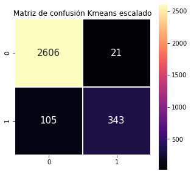

```python
fig, ax = plt.subplots(figsize=(5,5))

ax = sns.heatmap(CM, square=True, linewidths=.6, linecolor='white', cmap='magma',
            annot=True, annot_kws={"size": 15}, fmt='g')
ax.set_title('Matriz de confusión Kmeans escalado', fontsize=12);
```

Escalando las variables se obtienen resultados muy superiores.

### 2.2. Modelo Clustering jerárquico

El clústering jerárquico que junta o separa iterativamente clústers en función de la distancia entre ellos. En concreto, se va a usar el algoritmo *Agglomerative Clustering* , que agrupa los clústers de forma *bottom-up* , es decir, partiendo de los puntos individuales y agrupándolos por cercanía. Se va a utilizar la distancia euclídea como medida de distancia. El parámetro *ward* , por su parte, indica que lo que se debe minimizar es la varianza dentro del clúster.

Una vez más, se conoce el número de clústers que se desea encontrar, 2 (Sí fraudulento, No fraudulento)

```python
hc = AgglomerativeClustering(n_clusters=2, affinity='euclidean', linkage='ward')
y_hc = hc.fit_predict(X)
```

```python
np.unique(y_hc)
```

```
array([0, 1])
```

```python
CM = confusion_matrix(y, y_hc)
print('Confusion matrix:\n', CM)
AC = accuracy_score(y, y_hc)
print('\n Accuracy: ', round(AC, 3))
Fsc = f1_score(y, y_hc)
print('\n F1-score: ', round(Fsc, 3))
```

```
Confusion matrix:
 [[ 636 1991]
 [ 332  116]]

 Accuracy:  0.245

 F1-score:  0.091
```

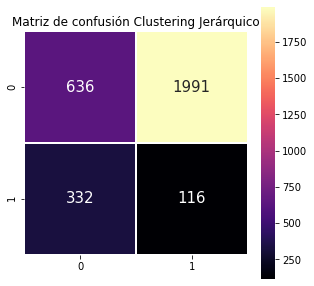

```python
fig, ax = plt.subplots(figsize=(5,5))

ax = sns.heatmap(CM, square=True, linewidths=.6, linecolor='white', cmap='magma',
            annot=True, annot_kws={"size": 15}, fmt='g')
ax.set_title('Matriz de confusión Clustering Jerárquico', fontsize=12);
```

En este caso, el F1-Score es extremadamente bajo, por lo que el modelo de clústering sería totalmente inútil. Una vez más, se va a probar si escalar los datos tiene beneficios.

```python
hc = AgglomerativeClustering(n_clusters=2, affinity='euclidean', linkage='ward')
y_hc = hc.fit_predict(X_sc)
```

```python
CM = confusion_matrix(y, y_hc)
print('Confusion matrix:\n', CM)
AC = accuracy_score(y, y_hc)
print('\n Accuracy: ', round(AC, 3))
Fsc = f1_score(y, y_hc)
print('\n F1-score: ', round(Fsc, 3))
```

```
Confusion matrix:
 [[   9 2618]
 [ 237  211]]

 Accuracy:  0.072

 F1-score:  0.129
```

Se observa una ligera mejoría en el F1-score, pero lejos aún de ser algo aceptable.

### 2.3. DBSCAN

DBSCAN (Density-Based Spatial Clustering of Applications with Noise) es un algoritmo de clustering creado en 1996, no paramétrico, basado en densidades, y que marca como outliers aquellos puntos que no superan un umbral de densidad establecido. Constituye uno de los algoritmos de clustering más usados y citados, y también es relativamente eficiente cuando se usan estructuras de datos adecuadas para su implementación (pudiendo llegar a ser de tiempo O(n2) en el peor caso).

```python
fitMe = X.to_numpy()

# Compute DBSCAN, eps (epsilon) determina la máxima distancia entre dos muestras para considerarlas vecinas
# En este escenario queremos forzar un resultado binario para poder determinar que casos son especiales de los no especiales, por lo tanto la epsilon es un valor grande
# En caso de querer detectar otros subconjuntos se puede conseguir con una epsilon más pequeña
db = DBSCAN(eps=20000, min_samples=1)
y_hc = db.fit_predict(X)
labels = db.labels_

# Number of clusters in labels, ignoring noise if present.
n_clusters_ = len(set(labels)) - (1 if -1 in labels else 0)
n_noise_ = list(labels).count(-1)

print('DBSCAN labels', labels)
print('n_clusters_', n_clusters_)
print('n_noise_', n_noise_)
```

```
DBSCAN labels [0 0 0 ... 0 0 0]
n_clusters_ 2
n_noise_ 0
```

```python
CM = confusion_matrix(y, y_hc)
print('Confusion matrix:\n', CM)
AC = accuracy_score(y, y_hc)
print('\n Accuracy: ', round(AC, 3))
Fsc = f1_score(y, y_hc, average='micro')
print('\n F1-score (micro): ', round(Fsc, 3))
Fsc = f1_score(y, y_hc, average='macro')
print('\n F1-score (macro): ', round(Fsc, 3))
```

```
Confusion matrix:
 [[2627    0]
 [ 446    2]]

 Accuracy:  0.855

 F1-score (micro):  0.855

 F1-score (macro):  0.465
```

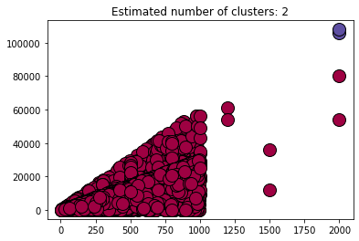

```python
# #############################################################################
# Plot result
import matplotlib.pyplot as plt

# Black removed and is used for noise instead.
unique_labels = set(labels)
colors = [plt.cm.Spectral(each)
          for each in np.linspace(0, 1, len(unique_labels))]

core_samples_mask = np.zeros_like(labels, dtype=bool)
core_samples_mask[db.core_sample_indices_] = True

for k, col in zip(unique_labels, colors):
    if k == -1:
        # Black used for noise.
        col = [0, 0, 0, 1]

    class_member_mask = (labels == k)

    xy = fitMe[class_member_mask & core_samples_mask]
    plt.plot(xy[:, 0], xy[:, 1], 'o', markerfacecolor=tuple(col),
             markeredgecolor='k', markersize=14)

    xy = fitMe[class_member_mask & ~core_samples_mask]
    plt.plot(xy[:, 0], xy[:, 1], 'o', markerfacecolor=tuple(col),
             markeredgecolor='k', markersize=6)

plt.title('Estimated number of clusters: %d' % n_clusters_)
plt.show()
```

## 3. Detección de anomalías

Se van a utilizar dos algoritmos, *Isolation Forest* y *Local Outlier Factor*.

### 3.1. Preparación de los datos

Se utilizan los mismos vectores que para clustering.

```python
X.head()
```

|  | Average Amount/transaction/day | Transaction_amount | Is declined | Total Number of declines/day | isForeignTransaction | isHighRiskCountry | Daily_chargeback_avg_amt |
| --- | --- | --- | --- | --- | --- | --- | --- |
| 0 | 100.0 | 3000.0 | 0 | 5 | 1 | 1 | 0 |
| 1 | 100.0 | 4300.0 | 0 | 5 | 1 | 1 | 0 |
| 2 | 185.5 | 4823.0 | 1 | 5 | 0 | 0 | 0 |
| 3 | 185.5 | 5008.5 | 1 | 8 | 0 | 0 | 0 |
| 4 | 500.0 | 26000.0 | 0 | 0 | 1 | 1 | 800 |

```python
y.head()
```

|  | isFradulent |
| --- | --- |
| 0 | 1 |
| 1 | 1 |
| 2 | 1 |
| 3 | 1 |
| 4 | 1 |

### 3.2. Modelo Isolation Forest

```python
if_mod = IsolationForest(n_estimators=100, contamination='auto', behaviour='new', random_state=42, bootstrap=False)
if_mod.fit(X)
y_if = if_mod.predict(X)
```

```python
np.unique(y_if, return_counts=True)
```

```
(array([-1,  1]), array([ 626, 2449]))
```

Dado que el -1 indica a las anomalías (lo fraudulento), se deberán convertir los 1 a 0 y los -1 a 1.

```python
y_if = y_if - 1
y_if[y_if<0] = 1
np.unique(y_if, return_counts=True)
```

```
(array([0, 1]), array([2449,  626]))
```

```python
CM_mlp = confusion_matrix(y, y_if)
print('Confusion matrix:\n', CM_mlp)
AC = accuracy_score(y, y_if)
print('\n Accuracy: ', round(AC, 3))
Fsc = f1_score(y, y_if)
print('\n F1-score: ', round(Fsc, 3))
```

```
Confusion matrix:
 [[2434  193]
 [  15  433]]

 Accuracy:  0.932

 F1-score:  0.806
```

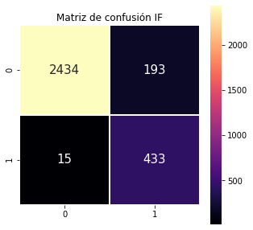

```python
fig, ax = plt.subplots(figsize=(5,5))

ax = sns.heatmap(CM_mlp, square=True, linewidths=.6, linecolor='white', cmap='magma',
            annot=True, annot_kws={"size": 15}, fmt='g')
ax.set_title('Matriz de confusión IF', fontsize=12);
```

Como se puede ver, los resultados con este algoritmo son bastante buenos.

### 3.3. Modelo Local Outlier Factor

```python
lof = LocalOutlierFactor(n_neighbors=50, contamination="auto", novelty=True)
lof_mod = lof.fit(X)
```

```python
y_lof = lof_mod.predict(X)
```

```python
np.unique(y_lof, return_counts=True)
```

```
(array([-1,  1]), array([ 130, 2945]))
```

Dado que el -1 indica a las anomalías (lo fraudulento), se deberán convertir los 1 a 0 y los -1 a 1.

```python
y_lof = y_lof - 1
y_lof[y_lof<0] = 1
np.unique(y_lof, return_counts=True)
```

```
(array([0, 1]), array([2945,  130]))
```

```python
CM_mlp = confusion_matrix(y, y_lof)
print('Confusion matrix:\n', CM_mlp)
AC = accuracy_score(y, y_lof)
print('\n Accuracy: ', round(AC, 3))
Fsc = f1_score(y, y_lof)
print('\n F1-score: ', round(Fsc, 3))
```

```
Confusion matrix:
 [[2565   62]
 [ 380   68]]

 Accuracy:  0.856

 F1-score:  0.235
```

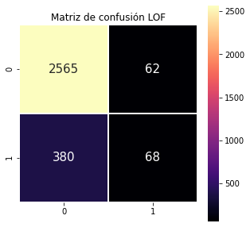

```python
fig, ax = plt.subplots(figsize=(5,5))

ax = sns.heatmap(CM_mlp, square=True, linewidths=.6, linecolor='white', cmap='magma',
            annot=True, annot_kws={"size": 15}, fmt='g')
ax.set_title('Matriz de confusión LOF', fontsize=12);
```

Con este otro algoritmo, por otro lado, los resultados son muy inferiores y totalmente inútiles como modelo de predicción.

## 4. Análisis de resultados de clasificación

Por lo tanto, en python, en modelo superior ha sido K-means en clustering, seguido por isolation forest como técnica de detección de anomalías.

## 5. Fuentes:

- https://towardsdatascience.com/dbscan-a-density-based-unsupervised-algorithm-for-fraud-detection-887c0f1016e9
- https://scikit-learn.org/stable/modules/generated/sklearn.cluster.DBSCAN.html